# Models With Images vs Without Images

Anonymous

2026-05-17

## 1 1. Load Data

```r
file_images <- "../output_csvs/image_comparison_grade_dist.csv"  # edit path if needed
file_reasoning <- "../output_csvs/openai_reasoning_comparison_grade_dist.csv"
file_sc_mc <- "../output_csvs/single_vs_multiple_context_grade_dist.csv"

raw <- readr::read_csv(file_images, show_col_types = FALSE)
raw_reasoning <- readr::read_csv(file_reasoning, show_col_types = FALSE)
raw_sc_mc <- readr::read_csv(file_sc_mc, show_col_types = FALSE)
glimpse(raw)
```

```
## Rows: 240
## Columns: 7
## $ ...1                    <dbl> 0, 1, 2, 3, 4, 5, 6, 7, 8, 9, 10, 11, 12, 13, …
## $ gpt4.1                  <dbl> 4.583333, 4.750000, 3.916667, 3.166667, 3.6000…
## $ gpt4.1_images           <dbl> 5.000000, 4.750000, 3.333333, 1.450000, 1.7500…
## $ o3_images               <dbl> 5.000000, 4.750000, 3.500000, 3.166667, 3.4166…
## $ o3                      <dbl> 5.000000, 4.750000, 1.000000, 1.666667, 1.7500…
## $ gemini_2.0_flash        <dbl> 1.833333, 4.625000, 1.916667, 1.700000, 1.1250…
## $ gemini_2.0_flash_images <dbl> 4.750000, 1.083333, 2.416667, 3.000000, 3.0714…
```

```r
glimpse(raw_reasoning)
```

```
## Rows: 240
## Columns: 13
## $ ...1           <dbl> 0, 1, 2, 3, 4, 5, 6, 7, 8, 9, 10, 11, 12, 13, 14, 15, 1…
## $ o3_pro         <dbl> 5.000000, 4.750000, 3.642857, 3.250000, 3.600000, 3.000…
## $ o3_high        <dbl> 5.000000, 4.750000, 1.000000, 1.666667, 1.750000, 2.250…
## $ o3_images_high <dbl> 5.000000, 4.750000, 3.500000, 3.166667, 3.416667, 1.000…
## $ o3_med         <dbl> 5.000000, 4.750000, 1.083333, 3.000000, 3.600000, 1.000…
## $ o3_images_med  <dbl> 5.000000, 4.750000, 3.500000, 3.166667, 3.600000, 2.250…
## $ o3_low         <dbl> 5.000000, 4.750000, 3.500000, 1.100000, 3.600000, 1.666…
## $ gpt5_high      <dbl> 5.000000, 4.750000, 3.916667, 3.200000, 3.400000, 3.916…
## $ gpt5_med       <dbl> 5.000000, 4.750000, 1.850000, 3.166667, 3.600000, 4.083…
## $ gpt5_low       <dbl> 5.000000, 4.750000, 1.333333, 1.000000, 3.600000, 2.500…
## $ gpt5_minimal   <dbl> 3.625000, 1.200000, 1.250000, 1.450000, 1.000000, 2.875…
## $ o4mini_high    <dbl> 5.000000, 4.750000, 3.916667, 1.000000, 1.666667, 2.000…
## $ o4mini_med     <dbl> 5.000000, 4.750000, 1.083333, 3.166667, 1.083333, 4.166…
```

```r
glimpse(raw_sc_mc)
```

```
## Rows: 120
## Columns: 21
## $ ...1                <dbl> 0, 1, 2, 3, 4, 5, 6, 7, 8, 9, 10, 11, 12, 13, 14, …
## $ sonnet_sc           <dbl> 5.000000, 4.750000, 1.000000, 3.750000, 3.600000, …
## $ sonnet_mc           <dbl> 5.000000, 2.900000, 1.250000, 1.100000, 3.600000, …
## $ gemini_2.0_flash_sc <dbl> 4.583333, 1.350000, 1.250000, 1.333333, 1.333333, …
## $ gemini_2.0_flash_mc <dbl> 1.833333, 4.625000, 1.916667, 1.700000, 1.125000, …
## $ gemini_2.5_pro_sc   <dbl> 5.000000, 4.750000, 1.083333, 1.000000, 1.083333, …
## $ gemini_2.5_pro_mc   <dbl> 5.000000, 5.000000, 1.916667, 1.700000, 1.750000, …
## $ chatgpt4o_sc        <dbl> 5.000000, 4.750000, 1.333333, 1.000000, 1.250000, …
## $ chatgpt4o_mc        <dbl> 4.500000, 4.583333, 1.350000, 3.500000, 3.416667, …
## $ gpt4.1_sc           <dbl> 5.000000, 4.750000, 1.000000, 1.000000, 1.250000, …
## $ gpt4.1_mc           <dbl> 4.583333, 4.750000, 3.916667, 3.166667, 3.600000, …
## $ gpt4.1_images_sc    <dbl> 5.000000, 1.350000, 1.416667, 3.166667, 1.750000, …
## $ gpt4.1_images_mc    <dbl> 5.000000, 4.750000, 3.333333, 1.450000, 1.750000, …
## $ o3_sc               <dbl> 5.000000, 4.750000, 1.550000, 3.750000, 3.600000, …
## $ o3_mc               <dbl> 5.000000, 4.750000, 3.500000, 3.750000, 2.900000, …
## $ o3_pro_sc           <dbl> 5.000000, 4.750000, 3.416667, 3.000000, 3.833333, …
## $ o3_pro_mc           <dbl> 5.000000, 4.750000, 3.642857, 3.250000, 3.600000, …
## $ o4_mini_sc          <dbl> 5.000000, 4.750000, 1.166667, 1.333333, 1.250000, …
## $ o4_mini_mc          <dbl> 5.000000, 4.750000, 3.916667, 1.000000, 1.666667, …
## $ o4_mini_med_sc      <dbl> 5.000000, 4.750000, 1.916667, 1.750000, 1.833333, …
## $ o4_mini_med_mc      <dbl> 5.000000, 4.750000, 1.083333, 3.166667, 1.083333, …
```

Assumptions (from the file):

- Column 1 (`Unnamed: 0`) is an index → we drop it.
- Remaining columns are model score distributions:
  - Plain models: e.g. `gpt4.1`, `o3`, `gemini_2.0_flash`
  - Image variants: e.g. `gpt4.1_images`, `o3_images`, `gemini_2.0_flash_images`

```r
# Drop index column
dat <- raw[, -1]
reasoning_dat <- raw_reasoning[, -1]
sc_mc_dat <- raw_sc_mc[, -1]

names(dat)
```

```
## [1] "gpt4.1"                  "gpt4.1_images"
## [3] "o3_images"               "o3"
## [5] "gemini_2.0_flash"        "gemini_2.0_flash_images"
```

```r
names(reasoning_dat)
```

```
##  [1] "o3_pro"         "o3_high"        "o3_images_high" "o3_med"
##  [5] "o3_images_med"  "o3_low"         "gpt5_high"      "gpt5_med"
##  [9] "gpt5_low"       "gpt5_minimal"   "o4mini_high"    "o4mini_med"
```

```r
names(sc_mc_dat)
```

```
##  [1] "sonnet_sc"           "sonnet_mc"           "gemini_2.0_flash_sc"
##  [4] "gemini_2.0_flash_mc" "gemini_2.5_pro_sc"   "gemini_2.5_pro_mc"
##  [7] "chatgpt4o_sc"        "chatgpt4o_mc"        "gpt4.1_sc"
## [10] "gpt4.1_mc"           "gpt4.1_images_sc"    "gpt4.1_images_mc"
## [13] "o3_sc"               "o3_mc"               "o3_pro_sc"
## [16] "o3_pro_mc"           "o4_mini_sc"          "o4_mini_mc"
## [19] "o4_mini_med_sc"      "o4_mini_med_mc"
```

## 2 2. Identify Image vs Non-Image Model Pairs

We assume image variants contain `_images` either at the end of the model name or before a context/reasoning suffix. For example:

- `gpt4.1_images` → `gpt4.1`
- `o3_images_high` → `o3_high`
- `gpt4.1_images_sc` → `gpt4.1_sc`

Pairs are discovered from the collapsed image comparison file, the OpenAI reasoning comparison file, and the single-vs-multiple-context file.

```r
discover_image_pairs <- function(source_dat, source_name) {
  image_cols <- names(source_dat)[str_detect(names(source_dat), "_images($|_)")]
  no_image_cols <- str_replace(image_cols, "_images($|_)", "\\1")

  tibble(
    base_model      = no_image_cols,
    no_image_col    = no_image_cols,
    image_model_col = image_cols,
    data_source     = source_name
  ) %>%
    filter(no_image_col %in% names(source_dat))
}

pairs <- bind_rows(
  discover_image_pairs(dat, "image_comparison"),
  discover_image_pairs(reasoning_dat, "reasoning_comparison"),
  discover_image_pairs(sc_mc_dat, "single_vs_multiple_context")
)

pairs
```

```
## # A tibble: 7 × 4
##   base_model       no_image_col     image_model_col         data_source
##   <chr>            <chr>            <chr>                   <chr>
## 1 gpt4.1           gpt4.1           gpt4.1_images           image_comparison
## 2 o3               o3               o3_images               image_comparison
## 3 gemini_2.0_flash gemini_2.0_flash gemini_2.0_flash_images image_comparison
## 4 o3_high          o3_high          o3_images_high          reasoning_comparison
## 5 o3_med           o3_med           o3_images_med           reasoning_comparison
## 6 gpt4.1_sc        gpt4.1_sc        gpt4.1_images_sc        single_vs_multiple_…
## 7 gpt4.1_mc        gpt4.1_mc        gpt4.1_images_mc        single_vs_multiple_…
```

At this point, for your file, `pairs` should look roughly like:

- `gpt4.1` ↔︎ `gpt4.1_images`
- `o3` ↔︎ `o3_images`
- `o3_high` ↔︎ `o3_images_high`
- `o3_med` ↔︎ `o3_images_med`
- `gemini_2.0_flash` ↔︎ `gemini_2.0_flash_images`
- `gpt4.1_sc` ↔︎ `gpt4.1_images_sc`
- `gpt4.1_mc` ↔︎ `gpt4.1_images_mc`

## 3 3. Long-Format Data for Plotting

```r
get_pair_dat <- function(source_name) {
  if (source_name == "image_comparison") {
    dat
  } else if (source_name == "reasoning_comparison") {
    reasoning_dat
  } else if (source_name == "single_vs_multiple_context") {
    sc_mc_dat
  } else {
    stop("Unknown data source: ", source_name)
  }
}

# Build a long data frame: model, variant (with/without images), score
long_list <- lapply(seq_len(nrow(pairs)), function(i) {
  base  <- pairs$base_model[i]
  noimg <- pairs$no_image_col[i]
  img   <- pairs$image_model_col[i]
  source_dat <- get_pair_dat(pairs$data_source[i])

  tibble(
    model_base = base,
    data_source = pairs$data_source[i],
    variant    = c(
      rep("no_images", nrow(source_dat)),
      rep("with_images", nrow(source_dat))
    ),
    score      = c(source_dat[[noimg]], source_dat[[img]])
  )
})

scores_long <- bind_rows(long_list)

scores_long
```

```
## # A tibble: 2,880 × 4
##    model_base data_source      variant   score
##    <chr>      <chr>            <chr>     <dbl>
##  1 gpt4.1     image_comparison no_images  4.58
##  2 gpt4.1     image_comparison no_images  4.75
##  3 gpt4.1     image_comparison no_images  3.92
##  4 gpt4.1     image_comparison no_images  3.17
##  5 gpt4.1     image_comparison no_images  3.6
##  6 gpt4.1     image_comparison no_images  4.17
##  7 gpt4.1     image_comparison no_images  1.08
##  8 gpt4.1     image_comparison no_images  4.17
##  9 gpt4.1     image_comparison no_images  1
## 10 gpt4.1     image_comparison no_images  1.42
## # ℹ 2,870 more rows
```

Quick summary:

```r
summary_stats <- scores_long %>%
  group_by(model_base, variant) %>%
  summarise(
    n      = n(),
    mean   = mean(score, na.rm = TRUE),
    median = median(score, na.rm = TRUE),
    sd     = sd(score, na.rm = TRUE),
    .groups = "drop"
  )

summary_stats
```

```
## # A tibble: 14 × 6
##    model_base       variant         n  mean median    sd
##    <chr>            <chr>       <int> <dbl>  <dbl> <dbl>
##  1 gemini_2.0_flash no_images     240  1.91   1.35  1.16
##  2 gemini_2.0_flash with_images   240  2.04   1.58  1.21
##  3 gpt4.1           no_images     240  2.12   1.45  1.32
##  4 gpt4.1           with_images   240  1.93   1.42  1.10
##  5 gpt4.1_mc        no_images     120  2.04   1.48  1.21
##  6 gpt4.1_mc        with_images   120  1.93   1.42  1.08
##  7 gpt4.1_sc        no_images     120  2.21   1.34  1.43
##  8 gpt4.1_sc        with_images   120  1.93   1.38  1.12
##  9 o3               no_images     240  3.13   3.33  1.44
## 10 o3               with_images   240  2.77   2.5   1.47
## 11 o3_high          no_images     240  3.13   3.33  1.44
## 12 o3_high          with_images   240  2.77   2.5   1.47
## 13 o3_med           no_images     240  2.82   2.71  1.54
## 14 o3_med           with_images   240  2.77   2.58  1.41
```

## 4 4. Visual Comparison

### 4.1 4.1 Boxplots per Model (with vs without images)

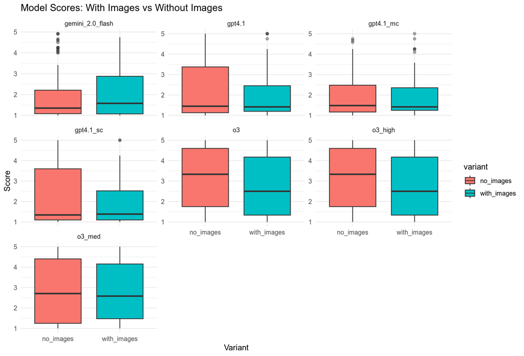

```r
scores_long %>%
  ggplot(aes(x = variant, y = score, fill = variant)) +
  geom_boxplot(outlier.alpha = 0.4) +
  facet_wrap(~ model_base, scales = "free_y") +
  labs(
    title = "Model Scores: With Images vs Without Images",
    x = "Variant",
    y = "Score"
  ) +
  theme_minimal()
```

### 4.2 4.2 Density Plot (stacked by model/variant)

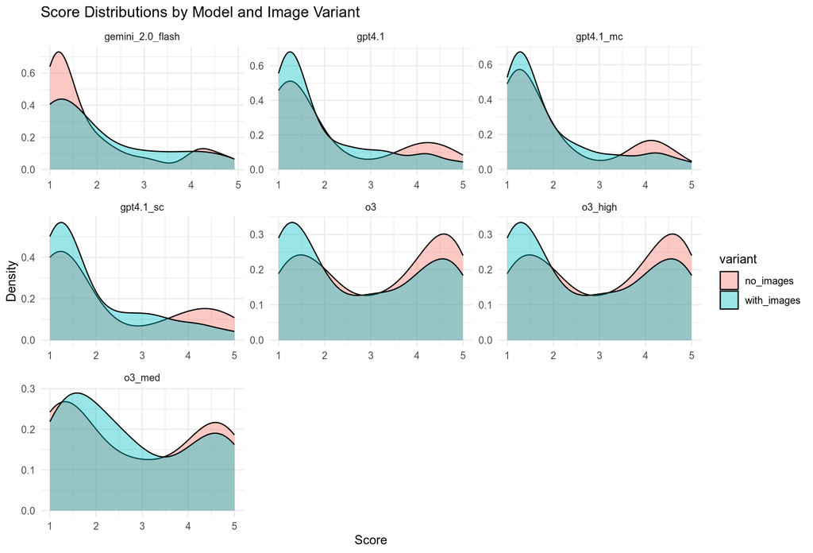

```r
scores_long %>%
  ggplot(aes(x = score, fill = variant)) +
  geom_density(alpha = 0.4) +
  facet_wrap(~ model_base, scales = "free") +
  labs(
    title = "Score Distributions by Model and Image Variant",
    x = "Score",
    y = "Density"
  ) +
  theme_minimal()
```

## 5 5. Mann–Whitney (Wilcoxon Rank-Sum) Tests

We treat the with-images and no-images distributions as **independent samples** and compare them using a Mann–Whitney U / Wilcoxon rank-sum test for each base model.

```r
mw_results <- purrr::map_df(
  seq_len(nrow(pairs)),
  ~{
    base <- pairs$base_model[.x]
    noimg <- pairs$no_image_col[.x]
    img  <- pairs$image_model_col[.x]
    source_dat <- get_pair_dat(pairs$data_source[.x])

    vec_noimg <- source_dat[[noimg]]
    vec_img   <- source_dat[[img]]

    test <- wilcox.test(vec_noimg, vec_img, exact = FALSE)

    broom::tidy(test) %>%
      mutate(
        model_base = base,
        no_image_col = noimg,
        image_model_col = img,
        data_source = pairs$data_source[.x]
      )
  }
)

mw_results
```

```
## # A tibble: 7 × 8
##   statistic p.value method   alternative model_base no_image_col image_model_col
##       <dbl>   <dbl> <chr>    <chr>       <chr>      <chr>        <chr>
## 1     7223  0.788   Wilcoxo… two.sided   gpt4.1     gpt4.1       gpt4.1_images
## 2    24828. 0.00872 Wilcoxo… two.sided   o3         o3           o3_images
## 3     2170. 0.711   Wilcoxo… two.sided   gemini_2.… gemini_2.0_… gemini_2.0_fla…
## 4    24828. 0.00872 Wilcoxo… two.sided   o3_high    o3_high      o3_images_high
## 5     1749  0.913   Wilcoxo… two.sided   o3_med     o3_med       o3_images_med
## 6     1880  0.675   Wilcoxo… two.sided   gpt4.1_sc  gpt4.1_sc    gpt4.1_images_…
## 7     1738  0.994   Wilcoxo… two.sided   gpt4.1_mc  gpt4.1_mc    gpt4.1_images_…
## # ℹ 1 more variable: data_source <chr>
```

### 5.1 5.1 Multiple-Comparison Correction

```r
mw_results_adj <- mw_results %>%
  mutate(
    p_adj_bonferroni = p.adjust(p.value, method = "bonferroni"),
    p_adj_fdr        = p.adjust(p.value, method = "fdr")
  ) %>%
  arrange(p_adj_bonferroni)

mw_results_adj
```

```
## # A tibble: 7 × 10
##   statistic p.value method   alternative model_base no_image_col image_model_col
##       <dbl>   <dbl> <chr>    <chr>       <chr>      <chr>        <chr>
## 1    24828. 0.00872 Wilcoxo… two.sided   o3_high    o3_high      o3_images_high
## 2    24828. 0.00872 Wilcoxo… two.sided   o3         o3           o3_images
## 3     7223  0.788   Wilcoxo… two.sided   gpt4.1     gpt4.1       gpt4.1_images
## 4     2170. 0.711   Wilcoxo… two.sided   gemini_2.… gemini_2.0_… gemini_2.0_fla…
## 5     1749  0.913   Wilcoxo… two.sided   o3_med     o3_med       o3_images_med
## 6     1880  0.675   Wilcoxo… two.sided   gpt4.1_sc  gpt4.1_sc    gpt4.1_images_…
## 7     1738  0.994   Wilcoxo… two.sided   gpt4.1_mc  gpt4.1_mc    gpt4.1_images_…
## # ℹ 3 more variables: data_source <chr>, p_adj_bonferroni <dbl>,
## #   p_adj_fdr <dbl>
```

```r
eff_results <- purrr::map_df(
  seq_len(nrow(pairs)),
  ~{
    base <- pairs$base_model[.x]
    noimg <- pairs$no_image_col[.x]
    img  <- pairs$image_model_col[.x]
    source_dat <- get_pair_dat(pairs$data_source[.x])

    vec_noimg <- source_dat[[noimg]]
    vec_img   <- source_dat[[img]]

    tmp <- tibble(
      score   = c(vec_noimg, vec_img),
      variant = c(
        rep("no_images", length(vec_noimg)),
        rep("with_images", length(vec_img))
      )
    )

    rstatix::wilcox_effsize(tmp, score ~ variant) %>%
      mutate(model_base = base, data_source = pairs$data_source[.x])
  }
)

eff_results
```

```
## # A tibble: 7 × 9
##   .y.   group1    group2    effsize    n1    n2 magnitude model_base data_source
##   <chr> <chr>     <chr>       <dbl> <int> <int> <ord>     <chr>      <chr>
## 1 score no_images with_ima… 1.75e-2   120   118 small     gpt4.1     image_comp…
## 2 score no_images with_ima… 1.28e-1   180   240 small     o3         image_comp…
## 3 score no_images with_ima… 2.97e-2   119    38 small     gemini_2.… image_comp…
## 4 score no_images with_ima… 1.28e-1   180   240 small     o3_high    reasoning_…
## 5 score no_images with_ima… 1.02e-2    60    59 small     o3_med     reasoning_…
## 6 score no_images with_ima… 3.85e-2    60    60 small     gpt4.1_sc  single_vs_…
## 7 score no_images with_ima… 9.93e-4    60    58 small     gpt4.1_mc  single_vs_…
```

## 7 7. Combined Summary Table

```r
# Objective differences: mean & median differences (with_images - no_images)
diff_summary <- purrr::map_df(
  seq_len(nrow(pairs)),
  ~{
    base <- pairs$base_model[.x]
    noimg <- pairs$no_image_col[.x]
    img  <- pairs$image_model_col[.x]
    source_dat <- get_pair_dat(pairs$data_source[.x])

    vec_noimg <- source_dat[[noimg]]
    vec_img   <- source_dat[[img]]

    tibble(
      model_base      = base,
      mean_no_images  = mean(vec_noimg, na.rm = TRUE),
      mean_with_images = mean(vec_img, na.rm = TRUE),
      median_no_images  = median(vec_noimg, na.rm = TRUE),
      median_with_images = median(vec_img, na.rm = TRUE),
      mean_diff       = mean(vec_img, na.rm = TRUE) - mean(vec_noimg, na.rm = TRUE),   # with - without
      median_diff     = median(vec_img, na.rm = TRUE) - median(vec_noimg, na.rm = TRUE),
      data_source     = pairs$data_source[.x]
    )
  }
)

summary_table <- mw_results_adj %>%
  select(
    data_source, model_base, no_image_col, image_model_col, statistic, p.value,
    p_adj_bonferroni, p_adj_fdr
  ) %>%
  left_join(
    eff_results %>% select(data_source, model_base, effsize, magnitude),
    by = c("data_source", "model_base")
  ) %>%
  left_join(diff_summary, by = c("data_source", "model_base")) %>%
  arrange(p_adj_bonferroni)

summary_table
```

```
## # A tibble: 7 × 16
##   data_source          model_base no_image_col image_model_col statistic p.value
##   <chr>                <chr>      <chr>        <chr>               <dbl>   <dbl>
## 1 reasoning_comparison o3_high    o3_high      o3_images_high     24828. 0.00872
## 2 image_comparison     o3         o3           o3_images          24828. 0.00872
## 3 image_comparison     gpt4.1     gpt4.1       gpt4.1_images       7223  0.788
## 4 image_comparison     gemini_2.… gemini_2.0_… gemini_2.0_fla…     2170. 0.711
## 5 reasoning_comparison o3_med     o3_med       o3_images_med       1749  0.913
## 6 single_vs_multiple_… gpt4.1_sc  gpt4.1_sc    gpt4.1_images_…     1880  0.675
## 7 single_vs_multiple_… gpt4.1_mc  gpt4.1_mc    gpt4.1_images_…     1738  0.994
## # ℹ 10 more variables: p_adj_bonferroni <dbl>, p_adj_fdr <dbl>, effsize <dbl>,
## #   magnitude <ord>, mean_no_images <dbl>, mean_with_images <dbl>,
## #   median_no_images <dbl>, median_with_images <dbl>, mean_diff <dbl>,
## #   median_diff <dbl>
```

## 8 8. Significance & Direction

```r
sig_table <- summary_table %>%
  mutate(
    significance = case_when(
      p_adj_bonferroni < 0.001 ~ "***",
      p_adj_bonferroni < 0.01  ~ "**",
      p_adj_bonferroni < 0.05  ~ "*",
      TRUE ~ "ns"
    ),
    direction = case_when(
      mean_diff >  0 ~ "with_images > no_images",
      mean_diff <  0 ~ "no_images > with_images",
      TRUE           ~ "no difference"
    )
  )

write_csv(sig_table, "../statistical_results/image_no_image_mann_whitney_summary.csv")
sig_table
```

```
## # A tibble: 7 × 18
##   data_source          model_base no_image_col image_model_col statistic p.value
##   <chr>                <chr>      <chr>        <chr>               <dbl>   <dbl>
## 1 reasoning_comparison o3_high    o3_high      o3_images_high     24828. 0.00872
## 2 image_comparison     o3         o3           o3_images          24828. 0.00872
## 3 image_comparison     gpt4.1     gpt4.1       gpt4.1_images       7223  0.788
## 4 image_comparison     gemini_2.… gemini_2.0_… gemini_2.0_fla…     2170. 0.711
## 5 reasoning_comparison o3_med     o3_med       o3_images_med       1749  0.913
## 6 single_vs_multiple_… gpt4.1_sc  gpt4.1_sc    gpt4.1_images_…     1880  0.675
## 7 single_vs_multiple_… gpt4.1_mc  gpt4.1_mc    gpt4.1_images_…     1738  0.994
## # ℹ 12 more variables: p_adj_bonferroni <dbl>, p_adj_fdr <dbl>, effsize <dbl>,
## #   magnitude <ord>, mean_no_images <dbl>, mean_with_images <dbl>,
## #   median_no_images <dbl>, median_with_images <dbl>, mean_diff <dbl>,
## #   median_diff <dbl>, significance <chr>, direction <chr>
```

## 9 9. Effect Size vs Adjusted p-value

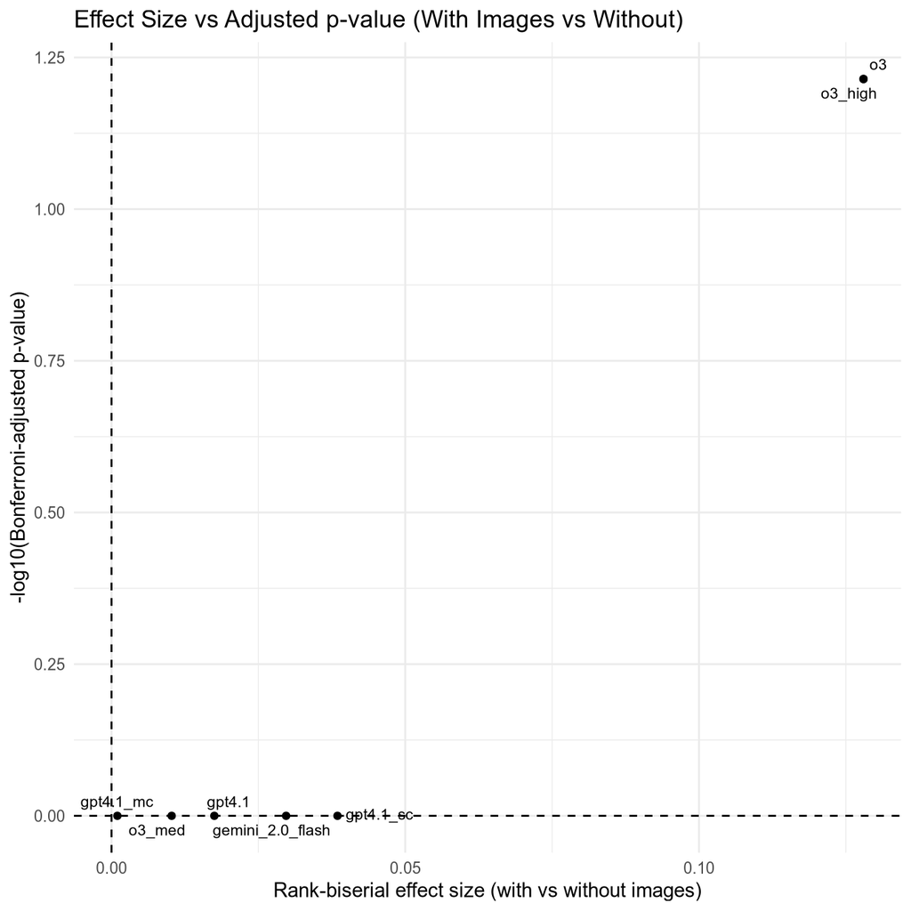

```r
sig_table %>%
  ggplot(aes(
    x = effsize,
    y = -log10(p_adj_bonferroni),
    label = model_base
  )) +
  geom_point() +
  ggrepel::geom_text_repel(size = 3, max.overlaps = 20) +
  geom_hline(yintercept = 0, linetype = "dashed") +   # horizontal at 0 (optional)
  geom_vline(xintercept = 0, linetype = "dashed") +   # vertical at 0 effect size
  labs(
    title = "Effect Size vs Adjusted p-value (With Images vs Without)",
    x = "Rank-biserial effect size (with vs without images)",
    y = "-log10(Bonferroni-adjusted p-value)"
  ) +
  theme_minimal()
```